# Data Wrangling with R tutorial

## Data Wrangling with R

https://ramnathv.github.io/pycon2014-r/explore/README.html

### Getting started

```r
#pkgs <- c('reshape2', 'plyr', 'ggplot2', 'dplyr', 'data.table', 'Lahman')
#install.packages(pkgs)
#install.packages('data.table')
#install.packages('Lahman')
#install.packages("tidyr")

library(reshape2)
library(plyr)
library(ggplot2)
library(dplyr)
library(data.table)
library(Lahman)

library(tidyr)

setwd("~/projects/Classes/FoundationsOfDataScience_sliderule/github/part4_data_wrangling/tutorial")
```

### Explore messy Data

https://ramnathv.github.io/pycon2014-r/explore/tidy.html

```r
pew <- read.delim(
#  file = "http://stat405.had.co.nz/data/pew.txt",
  file = "pew.txt",
  header = TRUE,
  stringsAsFactors = FALSE,
  check.names = F
)
head(pew)
```

```
##             religion <$10k $10-20k $20-30k $30-40k $40-50k $50-75k
## 1           Agnostic    27      34      60      81      76     137
## 2            Atheist    12      27      37      52      35      70
## 3           Buddhist    27      21      30      34      33      58
## 4           Catholic   418     617     732     670     638    1116
## 5 Don’t know/refused    15      14      15      11      10      35
## 6   Evangelical Prot   575     869    1064     982     881    1486
##   $75-100k $100-150k >150k Don't know/refused
## 1      122       109    84                 96
## 2       73        59    74                 76
## 3       62        39    53                 54
## 4      949       792   633               1489
## 5       21        17    18                116
## 6      949       723   414               1529
```

```r
tb <- read.csv(
#  file = "http://stat405.had.co.nz/data/tb.csv",
  file = "tb.csv",
  header = TRUE,
  stringsAsFactors = FALSE
)
head(tb)
```

```
##   iso2 year new_sp new_sp_m04 new_sp_m514 new_sp_m014 new_sp_m1524
## 1   AD 1989     NA         NA          NA          NA           NA
## 2   AD 1990     NA         NA          NA          NA           NA
## 3   AD 1991     NA         NA          NA          NA           NA
## 4   AD 1992     NA         NA          NA          NA           NA
## 5   AD 1993     15         NA          NA          NA           NA
## 6   AD 1994     24         NA          NA          NA           NA
##   new_sp_m2534 new_sp_m3544 new_sp_m4554 new_sp_m5564 new_sp_m65 new_sp_mu
## 1           NA           NA           NA           NA         NA        NA
## 2           NA           NA           NA           NA         NA        NA
## 3           NA           NA           NA           NA         NA        NA
## 4           NA           NA           NA           NA         NA        NA
## 5           NA           NA           NA           NA         NA        NA
## 6           NA           NA           NA           NA         NA        NA
##   new_sp_f04 new_sp_f514 new_sp_f014 new_sp_f1524 new_sp_f2534
## 1         NA          NA          NA           NA           NA
## 2         NA          NA          NA           NA           NA
## 3         NA          NA          NA           NA           NA
## 4         NA          NA          NA           NA           NA
## 5         NA          NA          NA           NA           NA
## 6         NA          NA          NA           NA           NA
##   new_sp_f3544 new_sp_f4554 new_sp_f5564 new_sp_f65 new_sp_fu
## 1           NA           NA           NA         NA        NA
## 2           NA           NA           NA         NA        NA
## 3           NA           NA           NA         NA        NA
## 4           NA           NA           NA         NA        NA
## 5           NA           NA           NA         NA        NA
## 6           NA           NA           NA         NA        NA
```

```r
weather <- read.delim(
# file = "http://stat405.had.co.nz/data/weather.txt",
 file = "weather.txt",
 stringsAsFactors = FALSE
)
head(weather)
```

```
##            id year month element d1  d2  d3 d4  d5 d6 d7 d8 d9 d10 d11 d12
## 1 MX000017004 2010     1    TMAX NA  NA  NA NA  NA NA NA NA NA  NA  NA  NA
## 2 MX000017004 2010     1    TMIN NA  NA  NA NA  NA NA NA NA NA  NA  NA  NA
## 3 MX000017004 2010     2    TMAX NA 273 241 NA  NA NA NA NA NA  NA 297  NA
## 4 MX000017004 2010     2    TMIN NA 144 144 NA  NA NA NA NA NA  NA 134  NA
## 5 MX000017004 2010     3    TMAX NA  NA  NA NA 321 NA NA NA NA 345  NA  NA
## 6 MX000017004 2010     3    TMIN NA  NA  NA NA 142 NA NA NA NA 168  NA  NA
##   d13 d14 d15 d16 d17 d18 d19 d20 d21 d22 d23 d24 d25 d26 d27 d28 d29 d30
## 1  NA  NA  NA  NA  NA  NA  NA  NA  NA  NA  NA  NA  NA  NA  NA  NA  NA 278
## 2  NA  NA  NA  NA  NA  NA  NA  NA  NA  NA  NA  NA  NA  NA  NA  NA  NA 145
## 3  NA  NA  NA  NA  NA  NA  NA  NA  NA  NA 299  NA  NA  NA  NA  NA  NA  NA
## 4  NA  NA  NA  NA  NA  NA  NA  NA  NA  NA 107  NA  NA  NA  NA  NA  NA  NA
## 5  NA  NA  NA 311  NA  NA  NA  NA  NA  NA  NA  NA  NA  NA  NA  NA  NA  NA
## 6  NA  NA  NA 176  NA  NA  NA  NA  NA  NA  NA  NA  NA  NA  NA  NA  NA  NA
##   d31
## 1  NA
## 2  NA
## 3  NA
## 4  NA
## 5  NA
## 6  NA
```

#### tb

Except for `iso2` and `year`, the rest of the columns headers are actually values of a lurking variable, in fact combination of **two** lurking variables, `gender` and `age`.

#### weather

This dataset seems to have two problems. First, it has variables in the rows in the column `element`. Second, it has a variable `d` in the column header spread across multiple columns.

```r
# # head(df)
# colnames(df) <- c("country", 1980:2007)
# #str(df)
# ldf <- gather(df, "year", "percentage", 2:29)
#
# # want the years to be numeric instead of factor?
# ldf$year_numeric <- with(ldf, as.numeric(levels(year))[year])
# # head(ldf)
# str(ldf)
```

#### Causes of Messiness

There are various features of messy data that one can observe in practice. Here are some of the more commonly observed patterns.

- Column headers are values, not variable names
- Multiple variables are stored in one column
- Variables are stored in both rows and columns
- Multiple types of experimental unit stored in the same table
- One type of experimental unit stored in multiple tables

### Reshape

```r
#library(reshape2)
pew_tidy <- melt(
  data = pew,
  id = "religion",
  variable.name = "income",
  value.name = "frequency"
)
# head(pew_tidy)
```

```r
#library(reshape2)

# set column `new_sp` to NULL and clean up column names
tb$new_sp = NULL
names(tb) <- gsub("new_sp_", "", names(tb))

# Use na.rm = TRUE to remove missing observations
tb_tidy <- melt(
  data = tb,
  id = c("iso2", "year"),
  variable.name = "gender_age",
  value.name = "cases",
  na.rm = TRUE
)
#head(tb_tidy)


# use regex substitutions to split gender_age into gender and age group
library(plyr)
tb_tidy <- mutate(tb_tidy,
  gender = sub("^([m|f])(.*)$", "\\1", gender_age),
  age = sub("^([m|f])(.*)$", "\\2", gender_age),
  gender_age = NULL
)
tb_tidy <- tb_tidy[c('iso2', 'year', 'gender', 'age', 'cases')]
#head(tb_tidy)
```

```r
library(reshape2)

# first melt the data and convert the day variable into numbers.
weather_tidy <- melt(
  data = weather,
  id = 1:4,
  variable.name = "day",   # d1-d31
  value.name = "temperature",
  na.rm = TRUE
)

# trim the /^d/ from the day column
weather_tidy <- mutate(weather_tidy,
  day = sub("^d", "", day)
)

weather_tidy2 <- dcast(
  data = weather_tidy,
  formula = id + year + month + day ~ element,
  value.var = "temperature"
)

head(weather_tidy)
```

```
##            id year month element day temperature
## 1 MX000017004 2010    12    TMAX   1         299
## 2 MX000017004 2010    12    TMIN   1         138
## 3 MX000017004 2010     2    TMAX   2         273
## 4 MX000017004 2010     2    TMIN   2         144
## 5 MX000017004 2010    11    TMAX   2         313
## 6 MX000017004 2010    11    TMIN   2         163
```

```r
head(weather_tidy2)
```

```
##            id year month day TMAX TMIN
## 1 MX000017004 2010     1  30  278  145
## 2 MX000017004 2010     2  11  297  134
## 3 MX000017004 2010     2   2  273  144
## 4 MX000017004 2010     2  23  299  107
## 5 MX000017004 2010     2   3  241  144
## 6 MX000017004 2010     3  10  345  168
```

#### billboards data

```r
billboards <- read.csv(
#  file = "http://stat405.had.co.nz/data/billboard.csv",
  file = "billboard.csv",
  stringsAsFactors = FALSE
)
names(billboards) <- gsub("\\.", "_", names(billboards))

# some more cleanup

# char encodings
billboards <- mutate(billboards,
  artist_inverted = iconv(artist_inverted, from = "MAC", to = "UTF-8")
)

# melt the x67th_week ... columns
billboards_tidy <- melt(billboards,
  id = 1:7,
  variable.name = "week",
  value.name = "rank",
  na.rm = TRUE
)

# now tweak the week format from 'x1st_week' to '1'
billboards_tidy <- mutate(billboards_tidy,
  week = as.numeric(gsub("^x([[:digit:]]+).*", "\\1", week))
)
```

### Summarize

```r
# https://ramnathv.github.io/pycon2014-r/explore/data/bnames2.csv.bz2
bnames2 <- read.csv("bnames2.csv.bz2")
```

#### summarize specific names

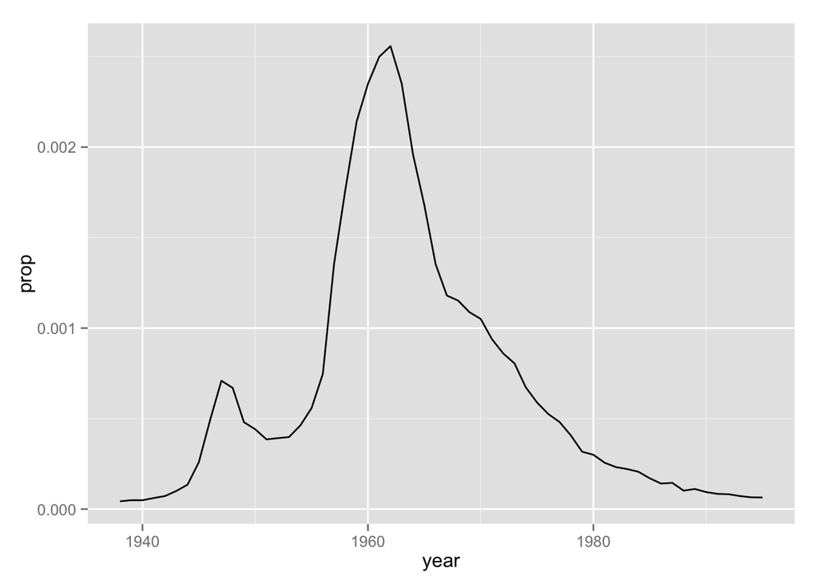

```r
greg <- subset(bnames2, name == "Greg")

#library(ggplot2)
qplot(x = year, y = prop, data = greg, geom = 'line')
```

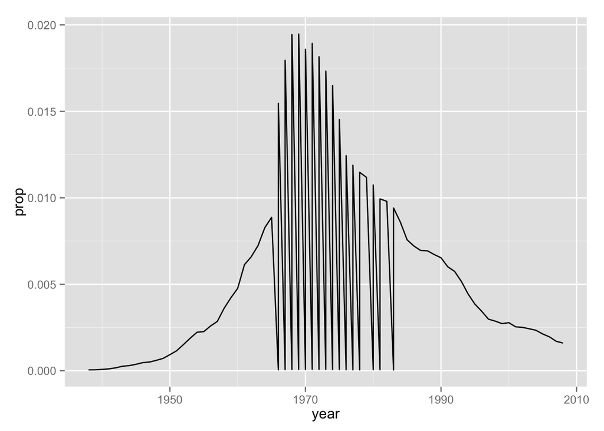

```r
michelle <- subset(bnames2, name == "Michelle")

#library(ggplot2)
qplot(x = year, y = prop, data = michelle, geom = 'line')
```

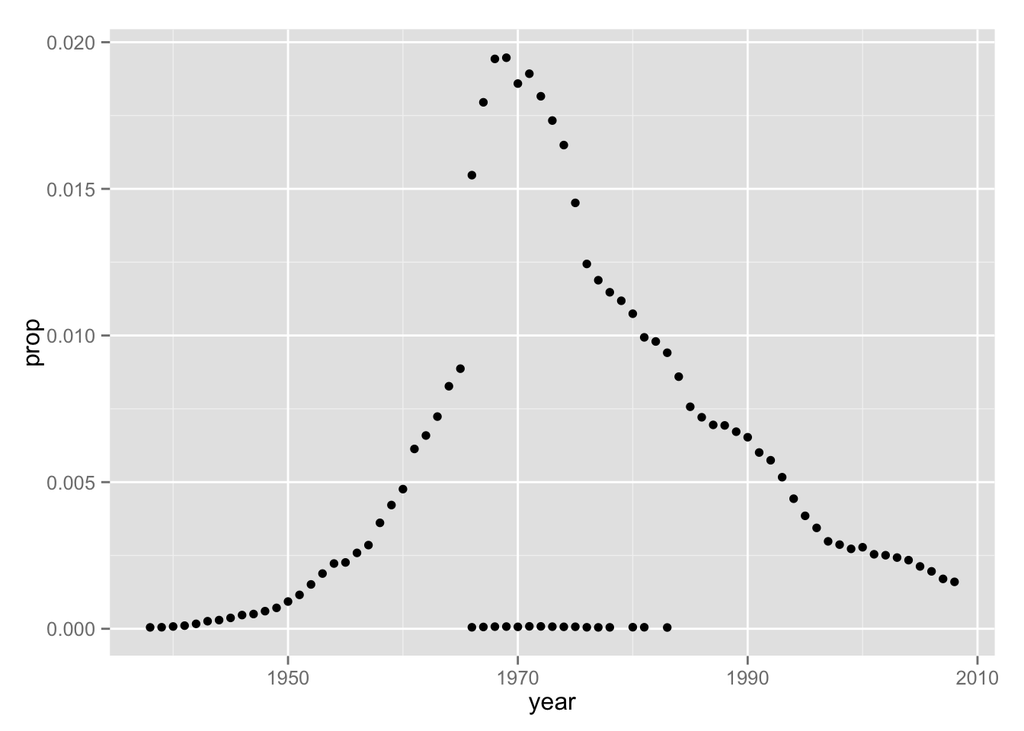

```r
qplot(x = year, y = prop, data = michelle, geom = 'point')
```

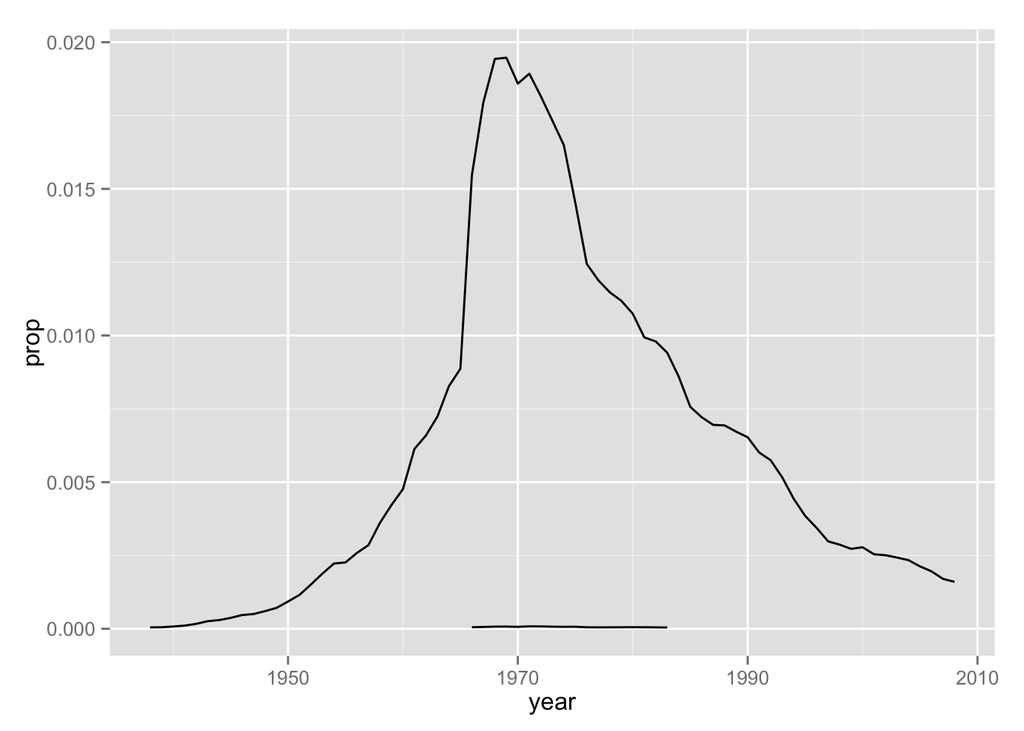

```r
### sawtooth in output, because of two genders ('sex')
qplot(x = year, y = prop, data = michelle, geom = 'line', group = sex)
```

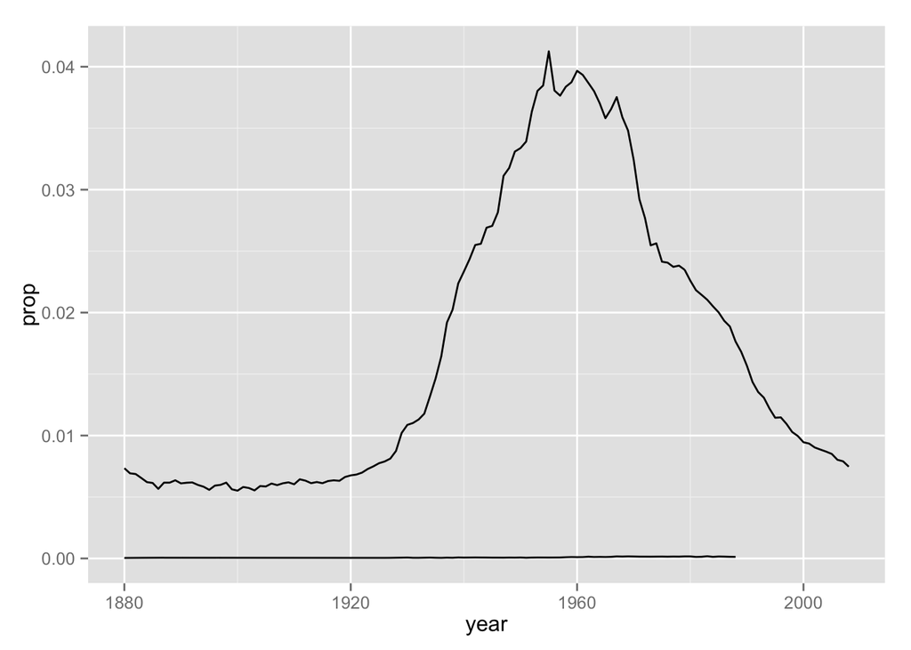

```r
david <- subset(bnames2, name == "David")
qplot(x = year, y = prop, data = david, geom = 'line', group = sex)
```

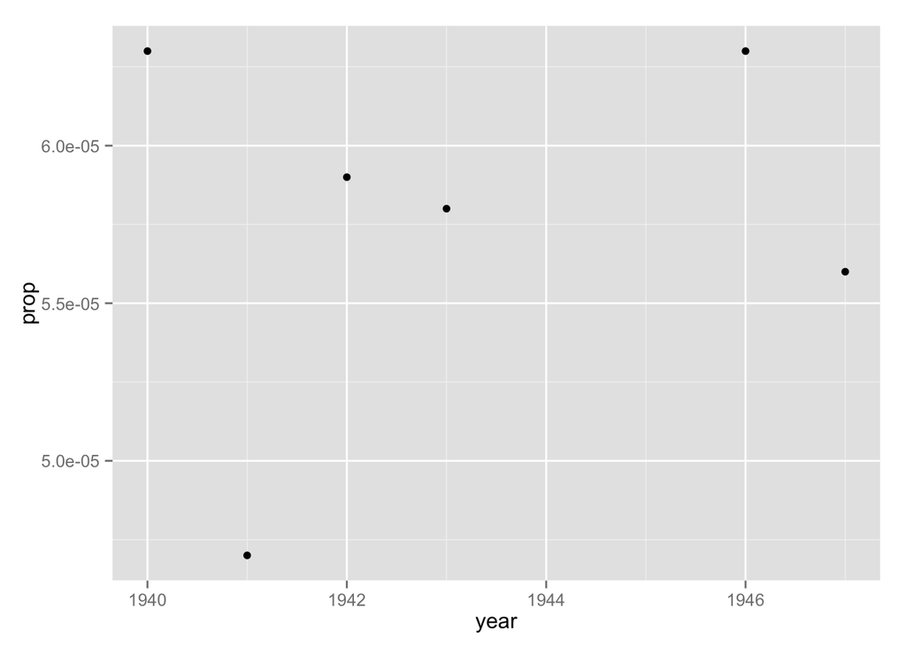

```r
ilona <- subset(bnames2, name == "Ilona")
qplot(x = year, y = prop, data = ilona, geom = 'point')
```

#### soundex

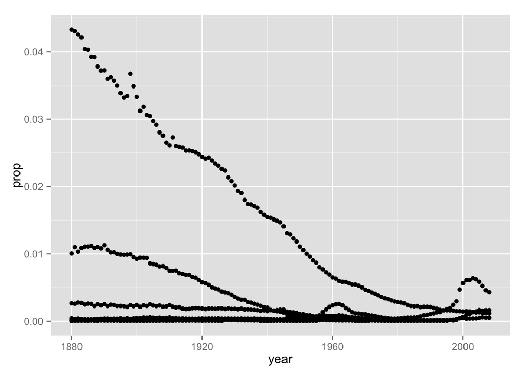

```r
greg_soundex = greg$soundex[1]
greg_like <- subset(bnames2, soundex == greg_soundex)
qplot(x = year, y = prop, data = greg_like, geom = 'point')
```

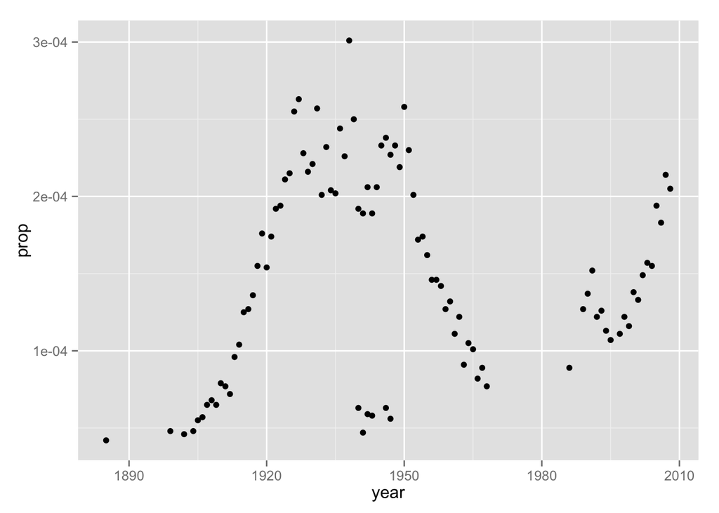

```r
ilona_soundex = ilona$soundex[1]
ilona_like <- subset(bnames2, soundex == ilona_soundex)
qplot(x = year, y = prop, data = ilona_like, geom = 'point')
```

```r
#qplot(x = year, y = prop, data = ilona_like, geom = 'line')
```

### data manipulation verbs

https://ramnathv.github.io/pycon2014-r/explore/data/births.csv

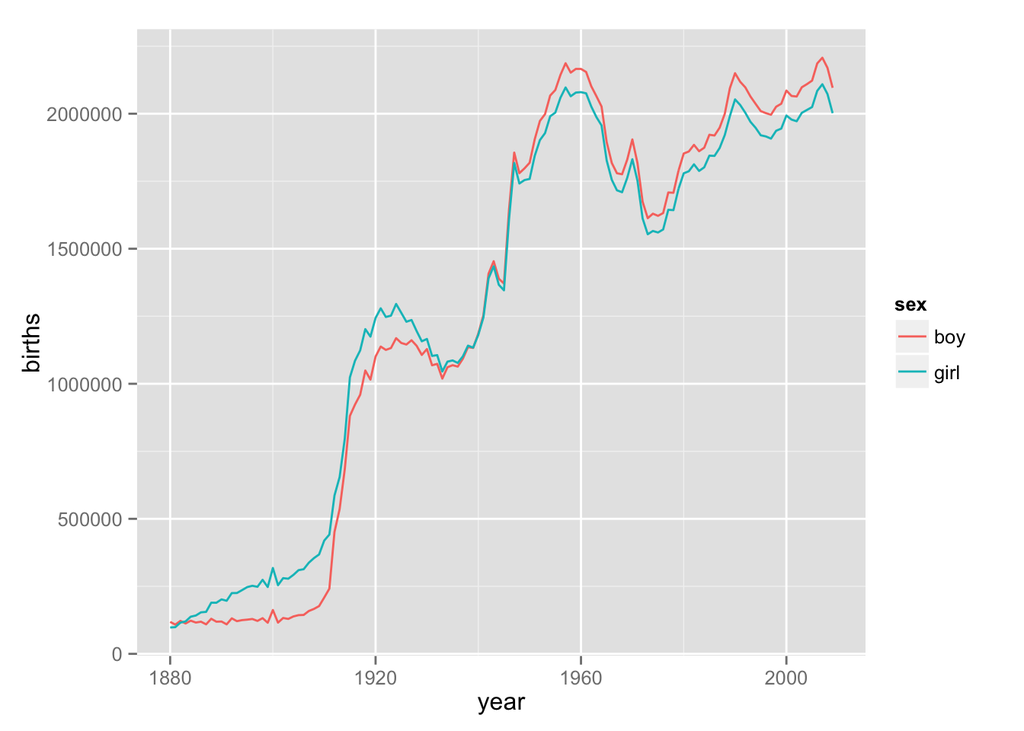

```r
births <- read.csv("births.csv")
qplot(year, births, data = births, color = sex, geom = 'line')
```

#### Join

```r
bnames2_b <- join(bnames2, births, by = c("sex", "year"))
```

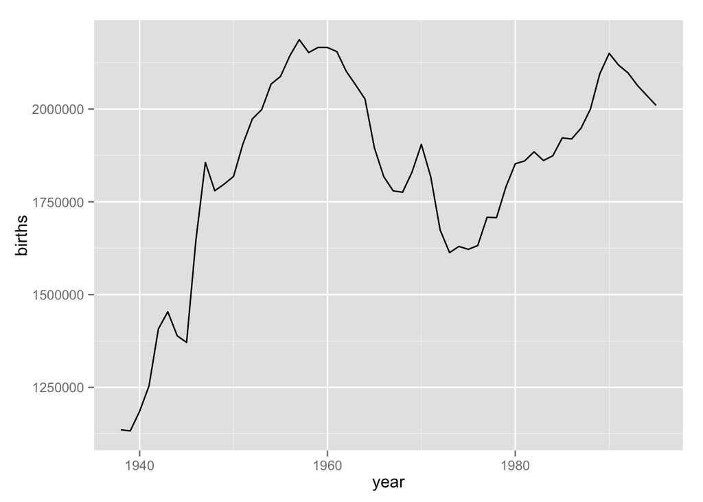

```r
greg <- subset(bnames2_b, name == 'Greg')
greg <- mutate(greg, tot = prop * births)
qplot(year, births, data = greg, geom = 'line')
```

### what is the most popular name in the US across all the years (1880 - 2008)?

```r
greg_tot <- summarize(greg, tot = sum(prop * births))
```

How do we do this for all names? In terms of pseudocode, here is what we would do.

- Split the dataset by name.
- Apply the summary computations to each name. = Combine the summaries created into a single dataset.

```r
# Split
pieces <- split(bnames2_b, bnames2_b$name)

# Apply
results <- vector("list", length(pieces))
for (i in seq_along(pieces)){
  results[[i]] <- summarize(pieces[[i]],
     name = name[1],
     tot = sum(prop * births)
  )
}

# Combine
result <- do.call("rbind", results)
```

```r
most_pop_name <- arrange(result, desc(tot))[1,"name"]
most_pop_name
```

```
## [1] James
## 6782 Levels: Aaden Aaliyah Aarav Aaron Ab Abagail Abb Abbey ... Zula
```